[figure not shown]

# **Prediction of Errors in the Execution of Assorted Weight-Training Exercises**

## **Introduction**

This study was performed on six male participants with ages between 20 and 28 years with little or minimal experience in regars to Weight-Training. Each were asked to peform one set of Unilateral Dumbell Biceps Curl consisting of 10 repetitions in the set using a relatively light, 1.25kg dumbbell in different ways:

- **Class A** - *Exactly according to the specification of the exercise*
- **Class B** - *Throwing the elbows to the front with each repetition*
- **Class C** - *Lifting the Dumbbell only halfway up with each repetition*
- **Class D** - *Lowering the Dumbbell only halway down with each repetition*
- **Class E** - *Throwing the hips to the front with each repetition*

Mounted sensors on each of the participants were located in their respective **gloves**, on their **armbands**, in their **lumbar support belts** and in each of the **dumbbells** used. All of which collected data on the “*Euler*” angles (**pitch, roll and yaw**). Additionally, there were readings and measurements recorded via the **raw accelerator, gyroscope, and magnetometer**. All of this information can be reviewed at the aforementioned [website](http://groupware.les.inf.puc-rio.br/har).

## **Downloading of Data**

As referenced earlier, the data for this course project comes from the [Human Activity Recognition DataSet](https://d396qusza40orc.cloudfront.net/predmachlearn/pml-training.csv) which is hosted by [Groupware@LES](http://groupware.les.inf.puc-rio.br/har):

```r
train_set_site <- "https://d396qusza40orc.cloudfront.net/predmachlearn/pml-training.csv"
test_set_site <- "https://d396qusza40orc.cloudfront.net/predmachlearn/pml-testing.csv"
download.file(train_set_site, destfile = "training_set.csv")
download.file(test_set_site, destfile = "testing_set.csv")
date_of_download <- date()
date_of_download
```

```
## [1] "Thu Apr 05 21:12:03 2018"
```

## **Reading of and Preprocessing the Dataset:**

```r
train_set <- read.csv("training_set.csv", header = TRUE, na.strings = c("NA", "#DIV/0!", ""), stringsAsFactors = FALSE)
test_set <- read.csv("testing_set.csv", header = TRUE, na.strings = c("NA", "#DIV/0!", ""), stringsAsFactors = FALSE)
```

Upon reviewing this data, the features of which *can* be classified into 3 specific Variables: **Measurement**, **Summary** and **“HouseKeeping”**. When looking at the “*summary*” variables, I can see they begin with, “**amplitude, avg, kurtosis, min, max, skewness, and stddev**”. These apply summary statistics on the “*measurement*” variables which begin with, “**accel, gyros, magnet, roll, pitch and yaw**”. The “*summary*” variables would obviously be the choice variable for my model because they would have drastically cut down on the number of observations and processing time and they also contain the core *measurement* variables. Unfortunately, the *“test_set”* contains only missing values, so making predictions using the *summary* variable would be NULL. Oh well.

I will be removing the **“HouseKeeping”** variables that contain the row numbers **“X”**, the time_stamps(**“”raw_timestamp_part_1“,”raw_timestamp_part_2“”, “cvtd_timestamp”**), and the measurement intervals, “**new_window and num_window**”.

```r
sum_variables_indexed <- grepl("^amplitude|^avg|^kurtosis|^min|^max|^skewness|^stddev"
                               , names(train_set))
sum_variables <- names(train_set)[!sum_variables_indexed]
train_df <- train_set[, sum_variables]
na_be_gone_index <- sapply(train_df, function(x)sum(is.na(x)))
fin_train_df <- train_df[, -c(1:7)]
fin_train_df <- fin_train_df[, colSums(is.na(fin_train_df))==0]
```

Furthermore, the **train_set** contains `19622` *rows* and `160` *variables*. Conversely, the **test_set** contains `20` *rows* and `160` variables. I also need to set the variables to their respective correct class so as to avoid making errors during the modeling phase.

### *Setting of Variables*

```r
fin_train_df$accel_arm_x <- as.numeric(fin_train_df$accel_arm_x)
fin_train_df$accel_arm_y <- as.numeric(fin_train_df$accel_arm_y)
fin_train_df$accel_arm_z <- as.numeric(fin_train_df$accel_arm_z)
fin_train_df$total_accel_arm <- as.numeric(fin_train_df$total_accel_arm)
fin_train_df$accel_belt_x <- as.numeric(fin_train_df$accel_belt_x)
fin_train_df$accel_belt_y <- as.numeric(fin_train_df$accel_belt_y)
fin_train_df$accel_belt_z <- as.numeric(fin_train_df$accel_belt_z)
fin_train_df$total_accel_belt <- as.numeric(fin_train_df$total_accel_belt)
fin_train_df$accel_dumbbell_x <- as.numeric(fin_train_df$accel_dumbbell_x)
fin_train_df$accel_dumbbell_y <- as.numeric(fin_train_df$accel_dumbbell_y)
fin_train_df$accel_dumbbell_z <- as.numeric(fin_train_df$accel_dumbbell_z)
fin_train_df$total_accel_dumbbell <- as.numeric(fin_train_df$total_accel_dumbbell)
fin_train_df$accel_forearm_x <- as.numeric(fin_train_df$accel_forearm_x)
fin_train_df$accel_forearm_y <- as.numeric(fin_train_df$accel_forearm_y)
fin_train_df$accel_forearm_z <- as.numeric(fin_train_df$accel_forearm_z)
fin_train_df$total_accel_forearm <- as.numeric(fin_train_df$total_accel_forearm)
fin_train_df$magnet_arm_x <- as.numeric(fin_train_df$magnet_arm_x)
fin_train_df$magnet_arm_y <- as.numeric(fin_train_df$magnet_arm_y)
fin_train_df$magnet_arm_z <- as.numeric(fin_train_df$magnet_arm_z)
fin_train_df$magnet_belt_x <- as.numeric(fin_train_df$magnet_belt_x)
fin_train_df$magnet_belt_y <- as.numeric(fin_train_df$magnet_belt_y)
fin_train_df$magnet_belt_z <- as.numeric(fin_train_df$magnet_belt_z)
fin_train_df$magnet_dumbbell_x <- as.numeric(fin_train_df$magnet_dumbbell_x)
fin_train_df$magnet_dumbbell_y <- as.numeric(fin_train_df$magnet_dumbbell_y)
fin_train_df$magnet_forearm_x <- as.numeric(fin_train_df$magnet_forearm_x)

fin_train_df$classe <- as.factor(fin_train_df$classe)
```

### *Checking Variables which contain zeroes*

```r
zed_index <- sapply(fin_train_df[,-53], sum)
zed_variables <- which(zed_index == 0)
zed_variables
```

```
## named integer(0)
```

```r
fin_train_df <- fin_train_df[-c(845, 867, 899, 7058, 8468, 9029, 9264, 11989, 17508),]
```

## **Creation of Training, Test & Validation sets of Data**

```r
set.seed(2018)
part_1 <- createDataPartition(y = fin_train_df$classe, p = .50, list = FALSE)
train_1_set <- fin_train_df[part_1,]
validation <- fin_train_df[-part_1,]
part_2 <- createDataPartition(y = validation$classe, p = 0.70, list = FALSE)
test_1_set <- validation[part_2,]
validate_1_set <- validation[-part_2,]
```

Below you will see a table showing the final datasets and how they are comprised:

Breakdown of Training/Testing & Validation DataSets

| Type_of_DataSet | Number.of.Variables | Number.of.Rows |
| --- | --- | --- |
| Training DataSet | 53 | 9808 |
| Testing DataSet | 53 | 6866 |
| Validation DataSet | 53 | 2939 |

## **Creation of Models**

I will begin by generating a Random Forest Model on the Training Dataset. Per the Instructions for this Project, I will be using the variable, “classe” as my dependent variable. The “classe” variable contains the important classification on whether or not the movement through the exercise was performed correctly. Additionally, it also provides me with what error was committed as per the “Introduction” section earlier. I am also including a 5-fold cross validation to improve my model as well as repeating it three times.

```r
train_model_control <- trainControl(method = "repeatedcv", number = 5, repeats = 3)
fit_all_train_model = train(classe ~ ., data = train_1_set, method = "rf", trControl = train_model_control)
```

### Assessment of Model 1 - Training DataSet

Upon examination of the results, I find it to be pretty accurate with a value of approximately 98.5%.

| mtry | Accuracy | Kappa | AccuracySD | KappaSD |
| --- | --- | --- | --- | --- |
| 2 | 0.9854540 | 0.9815973 | 0.0024442 | 0.0030934 |
| 27 | 0.9855898 | 0.9817701 | 0.0034984 | 0.0044280 |
| 52 | 0.9747821 | 0.9681002 | 0.0039412 | 0.0049889 |

|  | A | B | C | D | E | class.error |
| --- | --- | --- | --- | --- | --- | --- |
| A | 2783 | 4 | 0 | 0 | 2 | 0.0021513 |
| B | 20 | 1866 | 10 | 1 | 0 | 0.0163416 |
| C | 0 | 14 | 1687 | 10 | 0 | 0.0140269 |
| D | 0 | 4 | 35 | 1566 | 3 | 0.0261194 |
| E | 0 | 3 | 4 | 7 | 1789 | 0.0077648 |

I expect the error out of sample to be slightly less than the error in sample that was measured above. Now lets see how the predictions go against the Testing DataSet:

```r
pred_test_set <- predict(fit_all_train_model, newdata = test_1_set)
err_out_of_sample <- table(pred_test_set, test_1_set$classe)
accuracy_of_model <- confusionMatrix(pred_test_set, test_1_set$classe)
```

[output not shown]

The **confusionMatrix** function summarizes in detail the **accuracy, sensitivity, specificty** as well as other *parameters* of my model’s prediction by *class*. Let’s take a look at this:

|  | Sensitivity | Specificity | Pos Pred Value | Neg Pred Value | Precision | Recall | F1 | Prevalence | Detection Rate | Detection Prevalence | Balanced Accuracy |
| --- | --- | --- | --- | --- | --- | --- | --- | --- | --- | --- | --- |
| Class: A | 0.9959016 | 0.9969475 | 0.9923430 | 0.9983697 | 0.9923430 | 0.9959016 | 0.9941192 | 0.2842994 | 0.2831343 | 0.2853190 | 0.9964246 |
| Class: B | 0.9841867 | 0.9958469 | 0.9827068 | 0.9962066 | 0.9827068 | 0.9841867 | 0.9834462 | 0.1934168 | 0.1903583 | 0.1937081 | 0.9900168 |
| Class: C | 0.9807853 | 0.9943553 | 0.9734660 | 0.9959364 | 0.9734660 | 0.9807853 | 0.9771119 | 0.1743373 | 0.1709875 | 0.1756481 | 0.9875703 |
| Class: D | 0.9813499 | 0.9973868 | 0.9866071 | 0.9963453 | 0.9866071 | 0.9813499 | 0.9839715 | 0.1639965 | 0.1609380 | 0.1631226 | 0.9893683 |
| Class: E | 0.9897070 | 0.9998215 | 0.9992006 | 0.9976848 | 0.9992006 | 0.9897070 | 0.9944312 | 0.1839499 | 0.1820565 | 0.1822022 | 0.9947643 |

I have created a plot to showcase the relationship that exists between the *number of randomly selected predictors* and the *accuracy*. Accuracy of the model is at its highest point, when, **mtry**(the tuning parameter for caret) has the number of variables available for splitting at each tree node is at 27. [“mtry”](https://cran.r-project.org/web/packages/randomForest/randomForest.pdf) is defined as, ‘The number of Variables randomly sampled as canditates for each split.’ Keep this in mind whilst viewing the plot *below*:

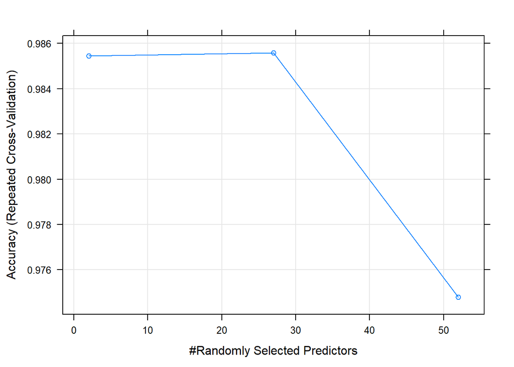

```r
plot(fit_all_train_model)
```

Next I want to check which features are highly **correlated** so as to decide which features to keep for the next model run. I want to hone the model so as to improve *processing time*, *scalability* as well as *interpretability*. Therefore I am going to take a look at the Features and see just how important each one is:

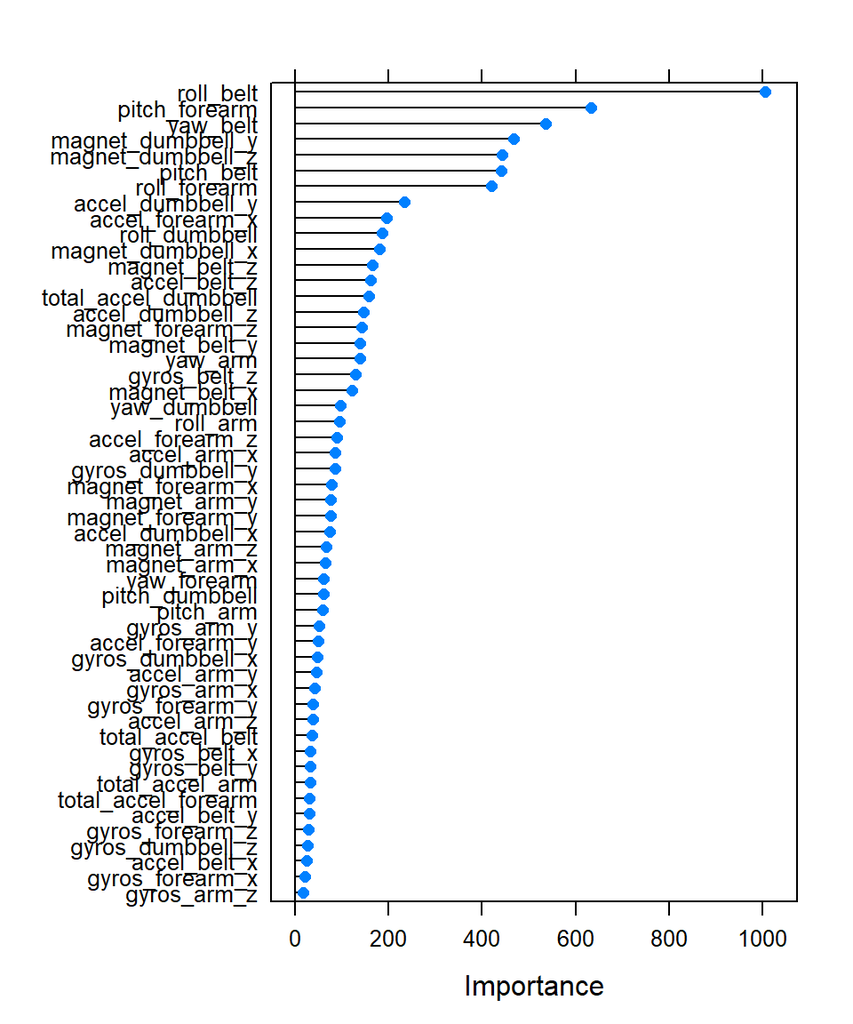

| names(train_1_set)[higher_cor] |
| --- |
| accel_belt_z |
| roll_belt |
| accel_belt_y |
| accel_dumbbell_z |
| accel_belt_x |
| pitch_belt |
| accel_dumbbell_x |
| accel_arm_x |
| magnet_arm_y |
| gyros_forearm_y |
| gyros_dumbbell_x |
| gyros_dumbbell_z |
| gyros_arm_x |

```r
final_model <- trainControl(method = "repeatedcv", number = 5, repeats = 3)
fit_train_13_model= train(classe ~ accel_belt_z + roll_belt + accel_belt_y + accel_dumbbell_x + accel_belt_x + pitch_belt + accel_dumbbell_x + accel_arm_x + magnet_arm_y + gyros_forearm_y + gyros_dumbbell_x + gyros_dumbbell_z + gyros_arm_x, data = train_1_set, method = "rf", trControl = final_model)
```

```r
pred_model_13 <- predict(fit_train_13_model, newdata = test_1_set)
accuracy_model_13 <- confusionMatrix(pred_model_13, test_1_set$classe)
```

[output not shown]

```r
fit_train_6_model = train(classe ~ accel_belt_z + roll_belt + accel_belt_y + accel_dumbbell_x + accel_belt_x + pitch_belt, data = train_1_set, method = "rf", trControl = final_model)
```

```r
pred_model_6 <- predict(fit_train_6_model, newdata = test_1_set)
accuracy_model_6 <- confusionMatrix(pred_model_6, test_1_set$classe)
```

|  | Sensitivity | Specificity | Pos Pred Value | Neg Pred Value | Precision | Recall | F1 | Prevalence | Detection Rate | Detection Prevalence | Balanced Accuracy |
| --- | --- | --- | --- | --- | --- | --- | --- | --- | --- | --- | --- |
| Class: A | 0.8580943 | 0.9163614 | 0.8029722 | 0.9420502 | 0.8029722 | 0.8580943 | 0.8296186 | 0.2842994 | 0.2439557 | 0.3038159 | 0.8872278 |
| Class: B | 0.8305723 | 0.9712893 | 0.8740095 | 0.9598501 | 0.8740095 | 0.8305723 | 0.8517375 | 0.1934168 | 0.1606467 | 0.1838043 | 0.9009308 |
| Class: C | 0.7719298 | 0.9585465 | 0.7972390 | 0.9521640 | 0.7972390 | 0.7719298 | 0.7843803 | 0.1743373 | 0.1345762 | 0.1688028 | 0.8652382 |
| Class: D | 0.7904085 | 0.9573171 | 0.7841410 | 0.9588205 | 0.7841410 | 0.7904085 | 0.7872623 | 0.1639965 | 0.1296242 | 0.1653073 | 0.8738628 |
| Class: E | 0.9326999 | 0.9917901 | 0.9624183 | 0.9849344 | 0.9624183 | 0.9326999 | 0.9473261 | 0.1839499 | 0.1715701 | 0.1782697 | 0.9622450 |

As predicted, sensitivity, specificity and accuracy all suffered from a decrease in the numbers with 6 variables. However, this model has better interpreability, scalability and faster processing time even though there is an increase in bias which reduced my capacity to predict accurately.

## Validation Set Model Fitting

Now I shall run the model on the validation test set to see how accurate it is. I will be running the model with all the variables and the one with only 6 to see the disparity between the two.

```r
pred_val_test_all <- predict(fit_all_train_model, newdata = validate_1_set)
accuracy_val_all <-confusionMatrix(pred_val_test_all, validate_1_set$classe)
pred_model_6b <- predict(fit_train_6_model, newdata = validate_1_set)
accuracy_model_6b <- confusionMatrix(pred_model_6b, validate_1_set$classe)
```

|  | Sensitivity | Specificity | Pos Pred Value | Neg Pred Value | Precision | Recall | F1 | Prevalence | Detection Rate | Detection Prevalence | Balanced Accuracy |
| --- | --- | --- | --- | --- | --- | --- | --- | --- | --- | --- | --- |
| Class: A | 0.9928230 | 0.9990490 | 0.9975962 | 0.9971523 | 0.9975962 | 0.9928230 | 0.9952038 | 0.2844505 | 0.2824090 | 0.2830895 | 0.9959360 |
| Class: B | 0.9929577 | 0.9945171 | 0.9774697 | 0.9983065 | 0.9774697 | 0.9929577 | 0.9851528 | 0.1932630 | 0.1919020 | 0.1963253 | 0.9937374 |
| Class: C | 0.9844055 | 0.9929926 | 0.9674330 | 0.9966901 | 0.9674330 | 0.9844055 | 0.9758454 | 0.1745492 | 0.1718272 | 0.1776114 | 0.9886990 |
| Class: D | 0.9792531 | 0.9987790 | 0.9936842 | 0.9959416 | 0.9936842 | 0.9792531 | 0.9864159 | 0.1640014 | 0.1605988 | 0.1616196 | 0.9890161 |
| Class: E | 0.9870370 | 1.0000000 | 1.0000000 | 0.9970906 | 1.0000000 | 0.9870370 | 0.9934762 | 0.1837360 | 0.1813542 | 0.1813542 | 0.9935185 |

[output not shown]

Please see the appendix for different plots which will show the misclassification of errors by the the models on the Validation Test Set.

## Predictions on the Test DataSet

I will now use the models created herein to Predict on the Downloaded Test DataSet:

```r
test_data <- test_set[ , which(names(test_set) %in% names(train_1_set))]
pred_test_all <- predict(fit_all_train_model, newdata = test_set)
print(pred_test_all)
```

```
##  [1] B A B A A E D B A A B C B A E E A B B B
## Levels: A B C D E
```

```r
pred_test_13 <- predict(fit_train_13_model, newdata = test_set)
print(pred_test_13)
```

```
##  [1] B A B A A E D C A A A C B A E E A B B B
## Levels: A B C D E
```

```r
pred_test_6 <- predict(fit_train_6_model, newdata = test_set)
print(pred_test_6)
```

```
##  [1] B C B D C E C D B A C C B D E E A B B B
## Levels: A B C D E
```

## Appendix

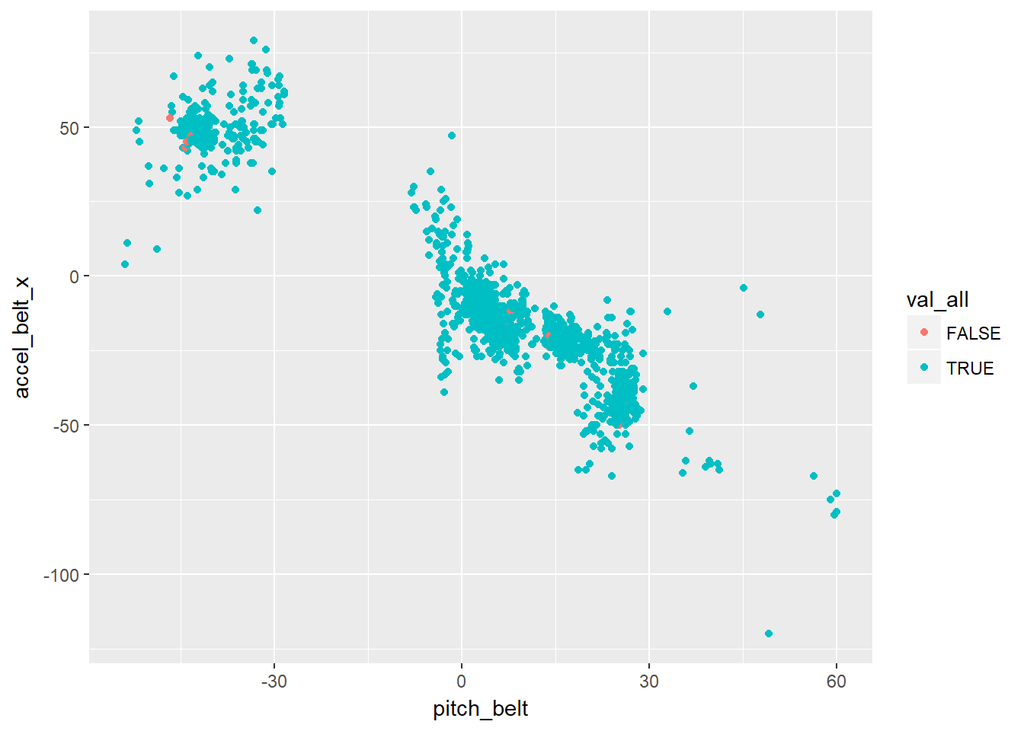

```r
val_all<- pred_val_test_all == validate_1_set$classe
qplot(pitch_belt, accel_belt_x, color = val_all, data = validate_1_set)
```

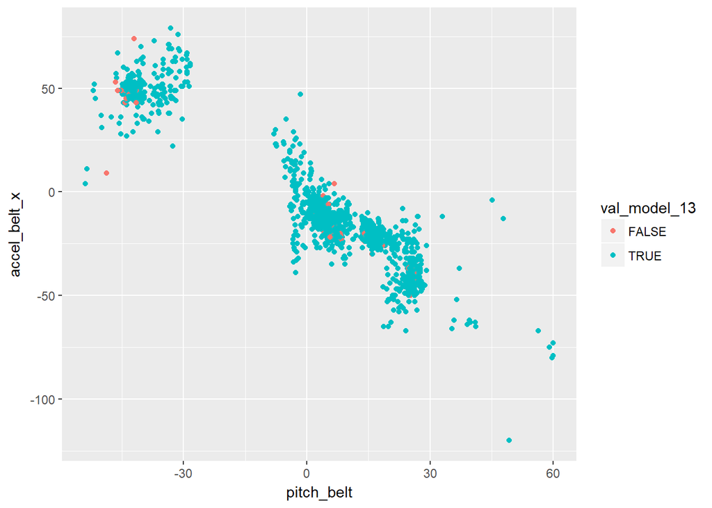

```r
pred_val_13 <- predict(fit_train_13_model, newdata = validate_1_set)
accuracy_val_13 <- confusionMatrix(pred_val_13, validate_1_set$classe)
val_model_13 <- pred_val_13 == validate_1_set$classe
qplot(pitch_belt, accel_belt_x, color = val_model_13, data = validate_1_set)
```

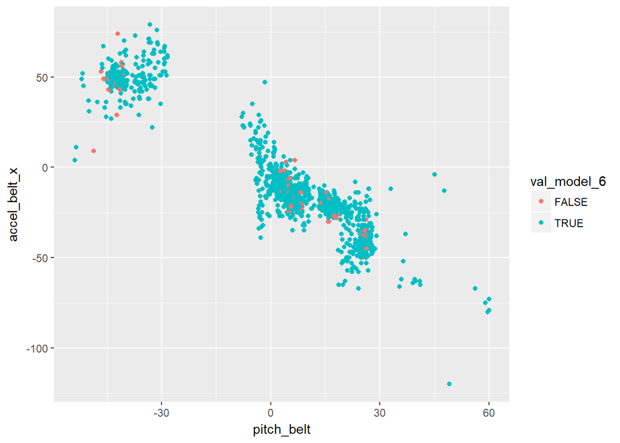

```r
pred_val_6 <- predict(fit_train_6_model, newdata = validate_1_set)
accuracy_val_6 <- confusionMatrix(pred_val_6, validate_1_set$classe)
val_model_6 <- pred_val_6 == validate_1_set$classe
qplot(pitch_belt, accel_belt_x, color = val_model_6, data = validate_1_set)
```